# An NPS-nalysis by Megan O'Bryan

```python
# Gotta start somewhere
import pandas as pd
import numpy as np
import seaborn as sns
import matplotlib.pylab as plt

data2017 = pd.read_csv("SA Feedback Surveys_FINAL/2017/Student Feedback Surveys-Superview.csv")
```

# Let's review our data

# I decided to use the data from 2017 exclusively, because it's well labeled and clearly rated

## 2016 had ratings that weren't out of 10

# Let's see what this gives us

```python
data2017.sample(5)
```

|  | ID | Location | Track | Week | Rating (Num) | Schedule Pacing |
| --- | --- | --- | --- | --- | --- | --- |
| 1452 | 1499 | New York City | Apps | Week 5 | 8 | Just right |
| 1201 | 1247 | San Francisco | VR | Week 7 | 10 | Just right |
| 591 | 622 | New York City | Apps | Week 2 | 5 | Just right |
| 1130 | 1175 | Tokyo | Apps | Week 1 | 10 | Just right |
| 578 | 609 | New York City | Games | Week 2 | 8 | Just right |

# I focused, first, on Sentiment, to determine NPS

# To convert, first I added the column "Sentiment"

```python
def determine_sentiment(rating):
    if (rating == "9") | (rating == "10"):
        return "Promoter"
    elif (rating == "7") | (rating == "8"):
        return "Passive"
    elif (rating == "1") | (rating == "2") | (rating == "3") | (rating == "4") | (rating == "5") | (rating == "6"):
        return "Detractor"
    elif (rating == "0"):
        return "Hater"
    else:
        return "Unknown"
```

```python
# Where the magic happens
data2017["Sentiment"] = data2017.apply(lambda row: determine_sentiment(row["Rating (Num)"]), axis=1)
```

# Looking at value_counts(), I could find the overall NPS

```python
data2017["Sentiment"].value_counts()
```

```
Promoter     760
Passive      569
Detractor    119
Unknown        3
Hater          2
Name: Sentiment, dtype: int64
```

```python
NPS = (760-119-2)/(760+569+119+2)*100
NPS
```

```
44.06896551724138
```

# I started wondering about the relationship between schedule pacing and sentiment

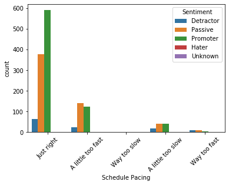

```python
sns.countplot(x="Schedule Pacing", hue="Sentiment", data=data2017)

plt.xticks(rotation=45)
```

## Since it's not normalized, the visualization isn't *super* useful; maybe something like value_counts() would be

```python
# Not exactly value counts, but I ended up using this pattern a lot
data2017.groupby(['Schedule Pacing', 'Sentiment']).size()
```

```
Schedule Pacing    Sentiment
A little too fast  Detractor     24
                   Hater          1
                   Passive      140
                   Promoter     124
A little too slow  Detractor     19
                   Passive       41
                   Promoter      40
Just right         Detractor     65
                   Passive      378
                   Promoter     591
Way too fast       Detractor      9
                   Hater          1
                   Passive        9
                   Promoter       4
Way too slow       Detractor      2
                   Passive        1
                   Promoter       1
dtype: int64
```

## This gives us a preliminary look, it seems like "Way too fast" and "Way too slow" are small groups (good) but give way to detraction more easily

## Also "A little too fast" has our other Hater :(

### Still we can have more precise data by calculating NPS for each Schedule Pacing

```python
def determine_NPS(category):
    try:
        promoter = category["Promoter"]
    except:
        promoter = 0
    try:
        passive = category["Passive"]
    except:
        passive = 0

    # haters and detractors have the same effect on NPS
    try:
        detractor = category["Detractor"]
    except:
        detractor = 0
    try:
        detractor += category["Hater"]
    except:
        pass
    return (promoter - detractor) / (passive + promoter + detractor) * 100
```

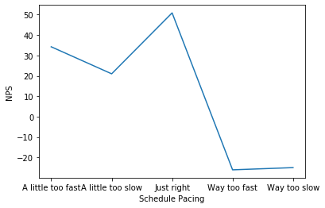

```python
sns.lineplot(x="Schedule Pacing", y="NPS", data=pacing_NPS_df)
```

# Evidently, I was wrong that all the students behind are the most miserable. "A little fast" is the second most enjoyable pacing.

# Next I want to find anomolies to this trend.

## Do some locations have low NPS and good pacing?

## Do some tracks have harsh pacing and high NPS?

# Location data

## We already have a function to find NPS; let's use that to graph Locational NPS

```
([0, 1, 2, 3, 4, 5, 6, 7, 8, 9, 10, 11],
 <a list of 12 Text xticklabel objects>)
```

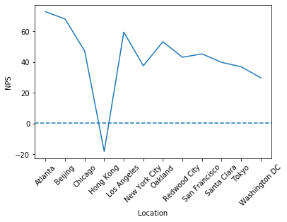

```python
ax = sns.lineplot(x="Location", y="NPS", data=location_NPS_df)

ax.axhline(0.5, ls='--')

plt.xticks(rotation=45)
```

# Atlanta, Beijing, Los Angeles and Oakland lead the way

# Now let's consider what our leaders pacing is, compared to HK's

```python
def determine_numeric_pacing(pacing):
    if pacing == "Way too fast":
        return 2
    elif pacing == "A little too fast":
        return 1
    elif pacing == "Just right":
        return 0
    elif pacing == "A little too slow":
        return -1
    elif pacing == "Way too slow":
        return -2
    else:
        return None
```

```python
# More magic column adding
data2017["Numeric Pacing"] = data2017.apply(lambda row: determine_numeric_pacing(row["Schedule Pacing"]), axis=1)
```

```python
data2017[data2017["Location"] == "Atlanta"]["Numeric Pacing"].mean()
```

```
0.12121212121212122
```

```python
data2017[data2017["Location"] == "Beijing"]["Numeric Pacing"].mean()
```

```
0.2564102564102564
```

```python
 data2017[data2017["Location"] == "Los Angeles"]["Numeric Pacing"].mean()
```

```
0.10377358490566038
```

```python
data2017[data2017["Location"] == "Oakland"]["Numeric Pacing"].mean()
```

```
0.1702127659574468
```

```python
data2017[data2017["Location"] == "Hong Kong"]["Numeric Pacing"].mean()
```

```
0.36363636363636365
```

# Is 0.2 too fast and Beijing an anomaly in terms of NPS?

# Is Hong Kong's fast pacing significant?

# Let's look at the tracks offered at Hong Kong.

```python
data2017[data2017["Location"] == "Hong Kong"]["Track"].value_counts()
```

```
Apps, Explorer    10
Apps               1
Name: Track, dtype: int64
```

# Apps and Apps, Explorer. Maybe this is the problem?

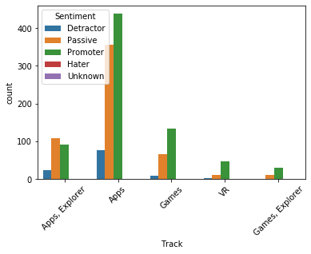

```python
sns.countplot(x="Track", hue="Sentiment", data=data2017)

plt.xticks(rotation=45)
```

# Apps, Explorer, I'm guessing, has the lowest NPS of all

```
([0, 1, 2, 3, 4], <a list of 5 Text xticklabel objects>)
```

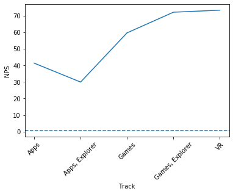

```python
ax = sns.lineplot(x="Track", y="NPS", data=track_NPS_df)

ax.axhline(0.5, ls='--')

plt.xticks(rotation=45)
```

# Apps, Explorer is the least promoted!

# Do other locations have this problem?

```python
data2017.groupby(['Location', 'Track']).size()
```

```
Location       Track
Atlanta        Apps                15
               Apps, Explorer      18
Beijing        Apps                76
               Apps, Explorer       2
Chicago        Apps                52
               Apps, Explorer      18
Hong Kong      Apps                 1
               Apps, Explorer      10
Los Angeles    Apps                75
               Games               31
New York City  Apps               194
               Apps, Explorer      49
               Games               59
               Games, Explorer     28
Oakland        Apps                39
               Apps, Explorer       8
Redwood City   Apps                58
San Francisco  Apps               155
               Apps, Explorer      77
               Games               68
               VR                  60
Santa Clara    Apps               111
               Apps, Explorer      25
               Games               50
               Games, Explorer     15
Tokyo          Apps                65
Washington DC  Apps                30
               Apps, Explorer      17
dtype: int64
```

# MOST locations don't offer Games or VR

## In fact, VR is ONLY offered in SF

# We can check if it's the pacing by checking the mean and deviation of our new Numeric Pacing column

```
([0, 1, 2, 3, 4, 5, 6, 7, 8, 9, 10, 11],
 <a list of 12 Text xticklabel objects>)
```

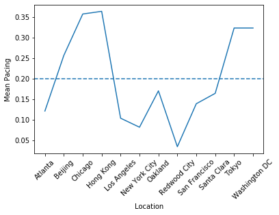

```python
ax = sns.lineplot(x="Location", y="Mean Pacing", data=location_pacing_df)

ax.axhline(0.2, ls='--')

plt.xticks(rotation=45)
```

# This confirms that Hong Kong's pacing IS fast, but not significantly more than in other cities

# What about the deviation?

```
([0, 1, 2, 3, 4, 5, 6, 7, 8, 9, 10, 11],
 <a list of 12 Text xticklabel objects>)
```

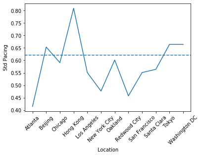

```python
ax = sns.lineplot(x="Location", y="Std Pacing", data=location_pacing_df)

ax.axhline(0.62, ls='--')

plt.xticks(rotation=45)
```

# Ahh, Hong Kong's deviation is much higher than others

# What does this tell us?

# Hong Kong's students are significantly not on the same page in terms of pacing

# They also have significantly low NPSs

# If we go back we'll see the top NPS scorer, Atlanta, has the lowest deviation in pacing.

# What else did we find out?

## Despite having the most offering SF did not have a top NPS

### SF also has decent pacing, so further analysis is required

### It should be noted things like environment, teachers, fellow students' behavior, CANNOT be determined with the given data

# NPS overall is about 44 of 100

## NPSs of all locations but Hong Kong are above 20

## Hong Kong's is -18